# Model 3: Mixed effects ordinal regression (stacked data)

## Model 1 (Most key predictors except for Frames)

Let’s start off with all the predictors with the exception of Frames (which we know drives everything). For the moment, we’ll use the Net Payer dummy.

#### Summary model 1

Given such a bare model, it’s not surprising that Level is important alongside some other story attributes such as word length and visibility.

```
Cumulative Link Mixed Model fitted with the Laplace approximation

formula: Tone ~ level + NetPayer + bad_thing17 + equi17 + vis4 + words +
    year2 + sourceFormat + (1 | country) + (1 | site)
data:    df

 link  threshold nobs logLik  AIC     niter      max.grad cond.H
 logit flexible  984  -936.20 1900.40 1353(4108) 1.19e-03 3.5e+03

Random effects:
 Groups  Name        Variance Std.Dev.
 site    (Intercept) 0.5974   0.7729
 country (Intercept) 0.1836   0.4285
Number of groups:  site 227,  country 8

Coefficients:
                        Estimate Std. Error z value Pr(>|z|)
levelNational           -0.71568    0.20215  -3.540   0.0004 ***
NetPayerYes             -0.64235    0.54182  -1.186   0.2358
bad_thing17              6.18279    3.27613   1.887   0.0591 .
equi17                   0.11989    0.27053   0.443   0.6576
vis4.L                  -0.54756    0.13686  -4.001 6.31e-05 ***
vis4.Q                   0.16965    0.12025   1.411   0.1583
words500-1000           -0.39275    0.15573  -2.522   0.0117 *
words+1000              -1.35077    0.26643  -5.070 3.98e-07 ***
year2                   -0.10517    0.09872  -1.065   0.2867
sourceFormatOnline only  0.31443    0.20224   1.555   0.1200
---
Signif. codes:  0 '***' 0.001 '**' 0.01 '*' 0.05 '.' 0.1 ' ' 1

Threshold coefficients:
                 Estimate Std. Error z value
Negative|Neutral -1.70785    0.65031  -2.626
Neutral|Positive -0.09881    0.64753  -0.153
(1 observation deleted due to missingness)
```

## Model2 (Key predictors plus Frames)

#### Summary model 2

Not surprisingly, most predictors fall out when Frames (dim) is included in the model.

```
Cumulative Link Mixed Model fitted with the Laplace approximation

formula: Tone ~ dim + level + NetPayer + bad_thing17 + equi17 + vis4 +
    words + year2 + sourceFormat + (1 | country) + (1 | site)
data:    df

 link  threshold nobs logLik  AIC     niter      max.grad cond.H
 logit flexible  984  -804.76 1639.53 1500(4584) 1.18e-04 3.4e+03

Random effects:
 Groups  Name        Variance Std.Dev.
 site    (Intercept) 0.7652   0.8748
 country (Intercept) 0.1674   0.4091
Number of groups:  site 227,  country 8

Coefficients:
                        Estimate Std. Error z value Pr(>|z|)
dimPolitics             -2.69414    0.18952 -14.215  < 2e-16 ***
levelNational           -0.26325    0.21990  -1.197  0.23126
NetPayerYes             -0.42788    0.54052  -0.792  0.42858
bad_thing17              4.37952    3.28467   1.333  0.18243
equi17                   0.27603    0.27126   1.018  0.30887
vis4.L                  -0.03261    0.15001  -0.217  0.82790
vis4.Q                   0.23534    0.12903   1.824  0.06817 .
words500-1000           -0.50913    0.16918  -3.009  0.00262 **
words+1000              -1.14126    0.28785  -3.965 7.35e-05 ***
year2                   -0.12357    0.10717  -1.153  0.24893
sourceFormatOnline only  0.07256    0.22251   0.326  0.74434
---
Signif. codes:  0 '***' 0.001 '**' 0.01 '*' 0.05 '.' 0.1 ' ' 1

Threshold coefficients:
                 Estimate Std. Error z value
Negative|Neutral  -3.3306     0.6728  -4.950
Neutral|Positive  -1.2487     0.6614  -1.888
(1 observation deleted due to missingness)
```

## Model 3 (Key predictors with interactions)

Let’s now add interaction effects across some of our key features.

#### Summary model 3

Adding the interactions, suggest only 2 of our core variables are signficant: Level and NetPayer.

```
Cumulative Link Mixed Model fitted with the Laplace approximation

formula: Tone ~ dim * (level + NetPayer + bad_thing17 + equi17) + vis4 +
    words + year2 + sourceFormat + (1 | country) + (1 | site)
data:    df

 link  threshold nobs logLik  AIC     niter      max.grad cond.H
 logit flexible  984  -793.00 1624.00 2175(6568) 2.59e-04 5.5e+03

Random effects:
 Groups  Name        Variance Std.Dev.
 site    (Intercept) 0.7957   0.8920
 country (Intercept) 0.1895   0.4353
Number of groups:  site 227,  country 8

Coefficients:
                          Estimate Std. Error z value Pr(>|z|)
dimPolitics               -4.78092    0.63684  -7.507 6.04e-14 ***
levelNational             -0.65682    0.27217  -2.413 0.015808 *
NetPayerYes               -1.13463    0.60987  -1.860 0.062823 .
bad_thing17                2.74573    3.83420   0.716 0.473920
equi17                     0.37187    0.30497   1.219 0.222701
vis4.L                     0.01257    0.15171   0.083 0.933957
vis4.Q                     0.23817    0.13093   1.819 0.068891 .
words500-1000             -0.47202    0.17107  -2.759 0.005794 **
words+1000                -1.12925    0.29246  -3.861 0.000113 ***
year2                     -0.12040    0.10848  -1.110 0.267049
sourceFormatOnline only    0.15372    0.22703   0.677 0.498337
dimPolitics:levelNational  0.88511    0.35996   2.459 0.013936 *
dimPolitics:NetPayerYes    1.51618    0.46860   3.236 0.001214 **
dimPolitics:bad_thing17    2.18759    3.06303   0.714 0.475110
dimPolitics:equi17        -0.09276    0.22075  -0.420 0.674339
---
Signif. codes:  0 '***' 0.001 '**' 0.01 '*' 0.05 '.' 0.1 ' ' 1

Threshold coefficients:
                 Estimate Std. Error z value
Negative|Neutral  -4.2993     0.7806  -5.507
Neutral|Positive  -2.1731     0.7653  -2.840
(1 observation deleted due to missingness)
```

## Model 4 (Optimal model)

Let’s now come up with an optimal model -having removed non-significant predictors.

#### Summary model 4

Here are the new coefficients for the optimal model.

```
Cumulative Link Mixed Model fitted with the Laplace approximation

formula: Tone ~ dim * (level + NetPayer) + vis4 + words + (1 | country) +
    (1 | site)
data:    df

 link  threshold nobs logLik  AIC     niter      max.grad cond.H
 logit flexible  984  -795.25 1616.49 1086(4348) 4.56e-04 1.1e+02

Random effects:
 Groups  Name        Variance Std.Dev.
 site    (Intercept) 0.8146   0.9026
 country (Intercept) 0.2578   0.5077
Number of groups:  site 227,  country 8

Coefficients:
                          Estimate Std. Error z value Pr(>|z|)
dimPolitics               -4.34456    0.42612 -10.196  < 2e-16 ***
levelNational             -0.64865    0.26801  -2.420 0.015510 *
NetPayerYes               -0.62605    0.45612  -1.373 0.169888
vis4.L                     0.01842    0.15092   0.122 0.902845
vis4.Q                     0.25069    0.13028   1.924 0.054325 .
words500-1000             -0.47321    0.17060  -2.774 0.005540 **
words+1000                -1.12718    0.29215  -3.858 0.000114 ***
dimPolitics:levelNational  0.88921    0.35742   2.488 0.012851 *
dimPolitics:NetPayerYes    1.37396    0.35600   3.859 0.000114 ***
---
Signif. codes:  0 '***' 0.001 '**' 0.01 '*' 0.05 '.' 0.1 ' ' 1

Threshold coefficients:
                 Estimate Std. Error z value
Negative|Neutral  -4.1196     0.4333  -9.508
Neutral|Positive  -1.9971     0.4073  -4.903
(1 observation deleted due to missingness)
```

# Comparison of models

We can make a check between model 3 and 4 to make sure there is no difference. As expected there isn’t a significant difference between the two models. So we keep the simpler, optimal model 4. And base the rest of the analysis on this model.

```
## Likelihood ratio tests of cumulative link models:
##
##    formula:
## m4 Tone ~ dim * (level + NetPayer) + vis4 + words + (1 | country) + (1 | site)
## m3 Tone ~ dim * (level + NetPayer + bad_thing17 + equi17) + vis4 + words + year2 + sourceFormat + (1 | country) + (1 | site)
##    link: threshold:
## m4 logit flexible
## m3 logit flexible
##
##    no.par    AIC  logLik LR.stat df Pr(>Chisq)
## m4     13 1616.5 -795.25
## m3     19 1624.0 -793.00  4.4905  6     0.6106
```

# Model 4: Plotting interactions

We will now plot the interactions. There were 2 signficant ones “Level” and “Net Payer (No/Yes)”. There are 2 ways to plot the interactions by flipping the x axis and the legend.

#### Interaction Net Payer (Frame*Net Payer)

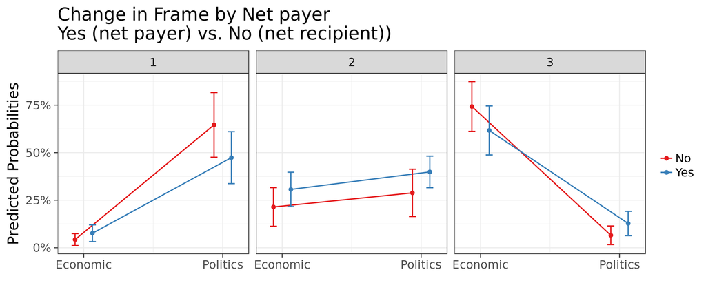

#### Interaction Net Payer (Net Payer*Frame)

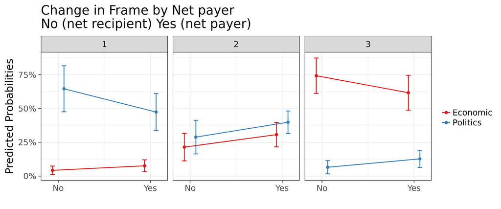

#### Interaction Level (Frame*Level)

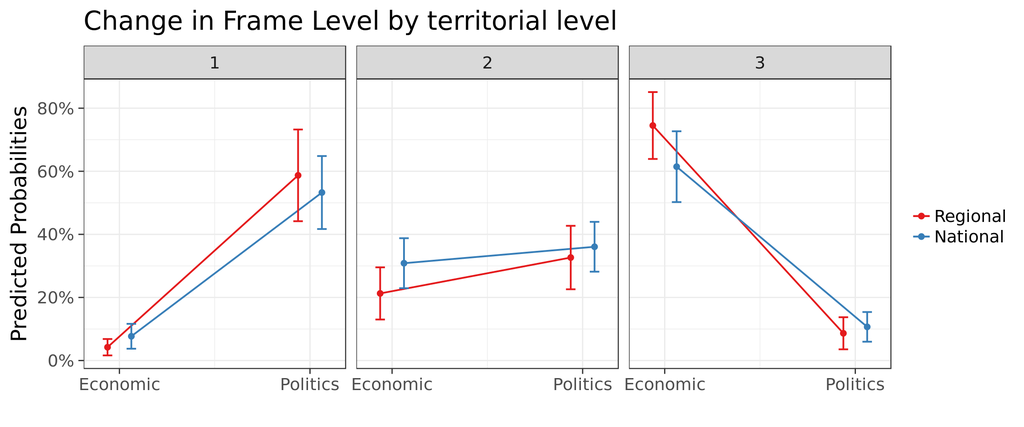

#### Interaction Level (Level*Frame)

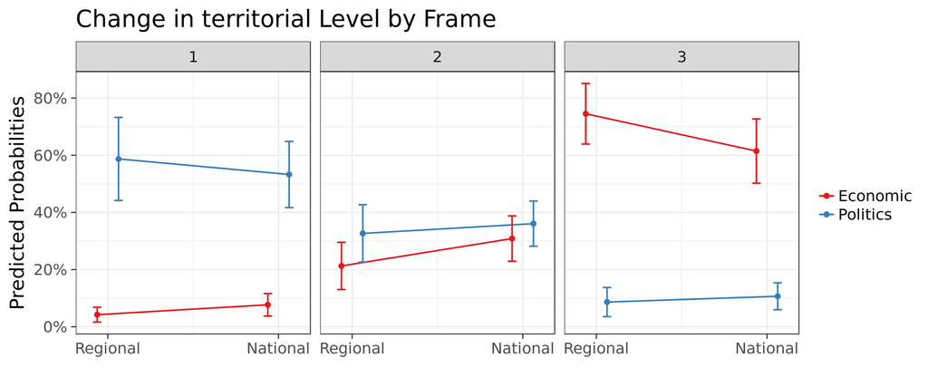

# Dilemma

Here we are confronted with a dilemma. I’ve included Net Payer, because it generates a result. However, if I include, say CP per capita, then you don’t get a result.

In short, if we want an additional, significant interaction then we should go with model 4 and Net Payer. Alternatively, the Annex below shows the regression outputs if we include a numeric version (in this case CP per capita). Note variables have to be standardised; it’s the (scale) function in the formula.

# Annex

## Model without Frames and interactions.

Only Level and the usual story level variables are significant.

```
## Cumulative Link Mixed Model fitted with the Laplace approximation
##
## formula:
## Tone ~ level + scale(cp_pc) + scale(bad_thing17) + scale(equi17) +
##     vis4 + words + year2 + sourceFormat + (1 | country) + (1 |      site)
## data:    df
##
##  link  threshold nobs logLik  AIC     niter      max.grad cond.H
##  logit flexible  984  -936.76 1901.51 1452(4420) 2.13e-03 7.3e+01
##
## Random effects:
##  Groups  Name        Variance Std.Dev.
##  site    (Intercept) 0.5963   0.7722
##  country (Intercept) 0.2221   0.4713
## Number of groups:  site 227,  country 8
##
## Coefficients:
##                         Estimate Std. Error z value Pr(>|z|)
## levelNational           -0.72192    0.20218  -3.571 0.000356 ***
## scale(cp_pc)            -0.16501    0.37768  -0.437 0.662185
## scale(bad_thing17)       0.32666    0.20351   1.605 0.108472
## scale(equi17)           -0.24861    0.36354  -0.684 0.494070
## vis4.L                  -0.55041    0.13681  -4.023 5.74e-05 ***
## vis4.Q                   0.16846    0.12023   1.401 0.161170
## words500-1000           -0.39348    0.15571  -2.527 0.011503 *
## words+1000              -1.34906    0.26653  -5.062 4.16e-07 ***
## year2                   -0.10310    0.09888  -1.043 0.297102
## sourceFormatOnline only  0.32179    0.20207   1.592 0.111279
## ---
## Signif. codes:  0 '***' 0.001 '**' 0.01 '*' 0.05 '.' 0.1 ' ' 1
##
## Threshold coefficients:
##                  Estimate Std. Error z value
## Negative|Neutral  -2.2845     0.3433  -6.655
## Neutral|Positive  -0.6755     0.3336  -2.025
## (1 observation deleted due to missingness)
```

Nothing really changes. Only Level and the usual story level variables are significant.

```
## Cumulative Link Mixed Model fitted with the Laplace approximation
##
## formula:
## Tone ~ dim * (level + scale(cp_pc) + scale(bad_thing17) + scale(equi17)) +
##     vis4 + words + year2 + sourceFormat + (1 | country) + (1 |      site)
## data:    df
##
##  link  threshold nobs logLik  AIC     niter      max.grad cond.H
##  logit flexible  984  -796.61 1631.22 2208(6750) 4.91e-04 1.2e+02
##
## Random effects:
##  Groups  Name        Variance Std.Dev.
##  site    (Intercept) 0.8128   0.9015
##  country (Intercept) 0.1579   0.3973
## Number of groups:  site 227,  country 8
##
## Coefficients:
##                                Estimate Std. Error z value Pr(>|z|)
## dimPolitics                    -3.47488    0.33401 -10.404  < 2e-16 ***
## levelNational                  -0.69898    0.27291  -2.561  0.01043 *
## scale(cp_pc)                   -0.04349    0.37735  -0.115  0.90824
## scale(bad_thing17)              0.07967    0.21194   0.376  0.70698
## scale(equi17)                  -0.08937    0.36557  -0.244  0.80687
## vis4.L                         -0.02503    0.15194  -0.165  0.86916
## vis4.Q                          0.27660    0.13103   2.111  0.03478 *
## words500-1000                  -0.49048    0.17026  -2.881  0.00397 **
## words+1000                     -1.13667    0.29212  -3.891 9.98e-05 ***
## year2                          -0.12146    0.10815  -1.123  0.26140
## sourceFormatOnline only         0.12469    0.22656   0.550  0.58207
## dimPolitics:levelNational       0.98260    0.35885   2.738  0.00618 **
## dimPolitics:scale(cp_pc)       -0.56226    0.31790  -1.769  0.07695 .
## dimPolitics:scale(bad_thing17)  0.30610    0.17760   1.724  0.08478 .
## dimPolitics:scale(equi17)       0.02665    0.28150   0.095  0.92459
## ---
## Signif. codes:  0 '***' 0.001 '**' 0.01 '*' 0.05 '.' 0.1 ' ' 1
##
## Threshold coefficients:
##                  Estimate Std. Error z value
## Negative|Neutral  -3.9915     0.3974 -10.044
## Neutral|Positive  -1.8673     0.3715  -5.026
## (1 observation deleted due to missingness)
```

### Compare models

Is there a difference between the more saturated interaction model, and the simpler one. The anova suggests there is a signficant difference, so we prefer the superior model.

```
## Likelihood ratio tests of cumulative link models:
##
##     formula:
## m0  Tone ~ level + scale(cp_pc) + scale(bad_thing17) + scale(equi17) + vis4 + words + year2 + sourceFormat + (1 | country) + (1 | site)
## m00 Tone ~ dim * (level + scale(cp_pc) + scale(bad_thing17) + scale(equi17)) + vis4 + words + year2 + sourceFormat + (1 | country) + (1 | site)
##     link: threshold:
## m0  logit flexible
## m00 logit flexible
##
##     no.par    AIC  logLik LR.stat df Pr(>Chisq)
## m0      14 1901.5 -936.76
## m00     19 1631.2 -796.61   280.3  5  < 2.2e-16 ***
## ---
## Signif. codes:  0 '***' 0.001 '**' 0.01 '*' 0.05 '.' 0.1 ' ' 1
```

#### Interaction Level (Frame*Level)

Let’s plot the 2 versions of the interaction. This models produces some very large confidence intervals - we don’t want to use them; suggest a very large range of uncertainty.

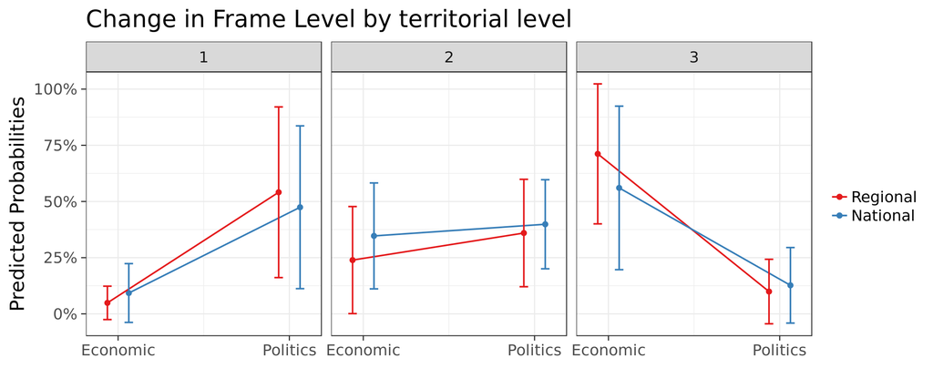

#### Interaction Level (Level*Frame)

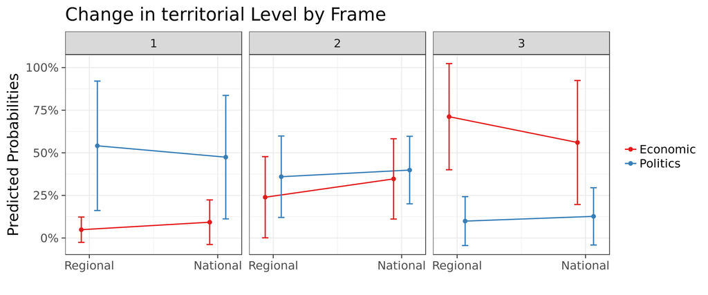

## Summary

It seems that optimal model 4 is the way to go. Slightly more of a story to tell there. We’ll need to tidy up the regression output and plots, but that’s relatively straightforward.

# Annex Annex

Last Annex, just a quick check whether “Net per capita balance” metric makes a difference as opposed to CP per capita balance. Regression output suggests identical results … it would not have made a difference to using CP per capita.

```
## Cumulative Link Mixed Model fitted with the Laplace approximation
##
## formula: Tone ~ dim * (level + scale(net_bal_pc) + scale(bad_thing17) +
##     scale(equi17)) + vis4 + words + year2 + sourceFormat + (1 |
##     country) + (1 | site)
## data:    df
##
##  link  threshold nobs logLik  AIC     niter      max.grad cond.H
##  logit flexible  984  -798.07 1634.14 2308(7048) 2.04e-03 1.1e+02
##
## Random effects:
##  Groups  Name        Variance Std.Dev.
##  site    (Intercept) 0.7993   0.8941
##  country (Intercept) 0.1923   0.4385
## Number of groups:  site 227,  country 8
##
## Coefficients:
##                                Estimate Std. Error z value Pr(>|z|)
## dimPolitics                    -3.46290    0.33332 -10.389  < 2e-16 ***
## levelNational                  -0.69003    0.27149  -2.542 0.011033 *
## scale(net_bal_pc)               0.23592    0.36983   0.638 0.523521
## scale(bad_thing17)              0.04752    0.22408   0.212 0.832054
## scale(equi17)                   0.13582    0.36091   0.376 0.706676
## vis4.L                         -0.01610    0.15159  -0.106 0.915393
## vis4.Q                          0.26189    0.13047   2.007 0.044719 *
## words500-1000                  -0.48516    0.17013  -2.852 0.004348 **
## words+1000                     -1.11980    0.29177  -3.838 0.000124 ***
## year2                          -0.12238    0.10806  -1.133 0.257414
## sourceFormatOnline only         0.12551    0.22588   0.556 0.578435
## dimPolitics:levelNational       0.98030    0.35844   2.735 0.006239 **
## dimPolitics:scale(net_bal_pc)  -0.25725    0.29100  -0.884 0.376681
## dimPolitics:scale(bad_thing17)  0.27214    0.17681   1.539 0.123753
## dimPolitics:scale(equi17)       0.23343    0.26241   0.890 0.373696
## ---
## Signif. codes:  0 '***' 0.001 '**' 0.01 '*' 0.05 '.' 0.1 ' ' 1
##
## Threshold coefficients:
##                  Estimate Std. Error z value
## Negative|Neutral  -3.9775     0.4016  -9.904
## Neutral|Positive  -1.8615     0.3763  -4.947
## (1 observation deleted due to missingness)
```